# matplotlib-1

## 四、图形内的文字、注释、箭头(自学)

控制文字属性的方法:

| Pyplot函数 | API方法 | 描述 |
| --- | --- | --- |
| text() | mpl.axes.Axes.text() | 在Axes对象的任意位置添加文字 |
| xlabel() | mpl.axes.Axes.set_xlabel() | 为X轴添加标签 |
| ylabel() | mpl.axes.Axes.set_ylabel() | 为Y轴添加标签 |
| title() | mpl.axes.Axes.set_title() | 为Axes对象添加标题 |
| legend() | mpl.axes.Axes.legend() | 为Axes对象添加图例 |
| figtext() | mpl.figure.Figure.text() | 在Figure对象的任意位置添加文字 |
| suptitle() | mpl.figure.Figure.suptitle() | 为Figure对象添加中心化的标题 |
| annnotate() | mpl.axes.Axes.annotate() | 为Axes对象添加注释（箭头可选） |

所有的方法会返回一个matplotlib.text.Text对象

### 图形内的文字

text()

[figure not shown]

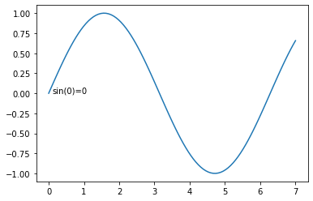

```python
x = np.linspace(0, 7, 100)
y = np.sin(x)
plt.plot(x,y)
# text在坐标系内添加文本说明
plt.text(0+0.1,0, 'sin(0)=0')
```

使用figtext()

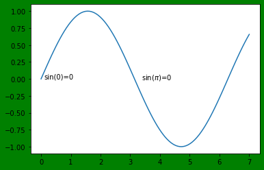

```python
x = np.linspace(0, 7, 100)
y = np.sin(x)
# plt.subplot(facecolor='g')
plt.figure(facecolor='g')
plt.plot(x,y)
# text在坐标系内添加文本说明
plt.text(0+0.1,0, 'sin(0)=0')
# figtext使用相对坐标
plt.figtext(0.5, 0.5, 'sin($\pi$)=0')
```

### 注释

annotate()  
xy参数设置箭头指示的位置，xytext参数设置注释文字的位置  
arrowprops参数以字典的形式设置箭头的样式  
width参数设置箭头长方形部分的宽度，headlength参数设置箭头尖端的长度，  
headwidth参数设置箭头尖端底部的宽度，  
facecolor设置箭头颜色  
shrink参数设置箭头顶点、尾部与指示点、注释文字的距离（比例值）

[figure not shown]

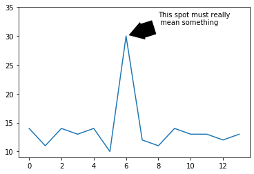

```python
n = [14, 11, 14,13,14,10, 30, 12, 11, 14, 13, 13, 12, 13]
plt.plot(n)
plt.ylim(ymax=35)
#     width        The width of the arrow in points
#     headwidth    The width of the base of the arrow head in points
#     headlength   The length of the arrow head in points
#     shrink       Fraction of total length to shrink from both ends
plt.annotate('This spot must really\n mean something',(6,30), (8,32), arrowprops=dict(width=20, headwidth=25, headlength=20, color='k', shrink=0.1))
```

练习  
三个随机正太分布数据

[figure not shown]

设置图例  
bbox_to_anchor,ncol mode,borderaxespad  
设置注解 arrowstyle

```python
n1 = np.random.normal(loc=10, scale=3, size=100)
n2 = np.random.normal(loc=20, scale=2, size=100)
n3 = np.random.normal(loc=30, scale=4, size=100)
```

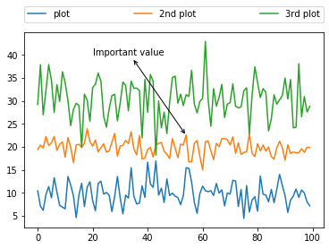

```python
plt.plot(n1, label='plot')
plt.plot(n2, label='2nd plot')
plt.plot(n3, label='3rd plot')
# plt.legend(loc=(0,1.05), ncol=3, mode='expand', borderaxespad=0)
plt.legend(loc=(0,1.05), ncol=3, mode='expand', borderaxespad=0, bbox_to_anchor=[0,1,1,0.05])
# ['-', '->', '-[', '<-', '<->', 'fancy', 'simple', 'wedge']
plt.annotate('Important value', (54, 22.5), (20, 40), arrowprops=dict(arrowstyle='<->'))
```

### 箭头

箭头的样式，没必要记

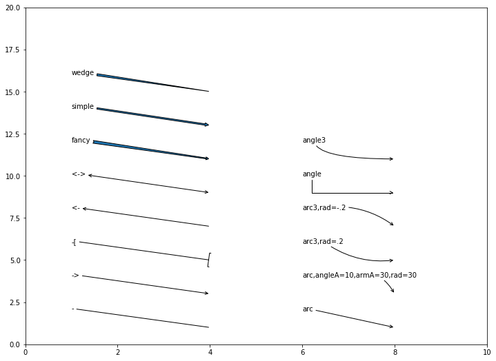

```python
plt.figure(figsize=(12,9))
plt.axis([0, 10, 0, 20]);
arrstyles = ['-', '->', '-[', '<-', '<->', 'fancy', 'simple', 'wedge']
for i, style in enumerate(arrstyles):
    plt.annotate(style, xytext=(1, 2+2*i), xy=(4, 1+2*i), arrowprops=dict(arrowstyle=style));

connstyles=["arc", "arc,angleA=10,armA=30,rad=30", "arc3,rad=.2", "arc3,rad=-.2", "angle", "angle3"]
for i, style in enumerate(connstyles):
    plt.annotate(style, xytext=(6, 2+2*i), xy=(8, 1+2*i), arrowprops=dict(arrowstyle='->', connectionstyle=style));
plt.show()
```

## 五、3D图(自学)

#### 曲面图

[figure not shown]

导包  
from mpl_toolkits.mplot3d.axes3d import Axes3D

```python
from mpl_toolkits.mplot3d.axes3d import Axes3D
```

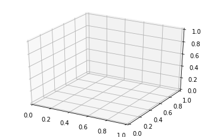

```python
plt.subplot(projection='3d')
```

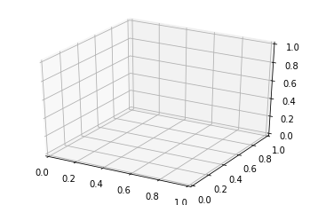

```python
# get current axes
plt.gca(projection='3d')
```

生成数据

```python
Z = X + Y + C
```

```python
x, y = [1,2,3], [2,3,4]
np.meshgrid(x, y)
```

```
[array([[1, 2, 3],
        [1, 2, 3],
        [1, 2, 3]]), array([[2, 2, 2],
        [3, 3, 3],
        [4, 4, 4]])]
```

```python
x, y = np.linspace(0, 7, 100), np.linspace(0,7, 100)
X,  Y= np.meshgrid(x,y)
```

```python
# 三维图形的方程
Z = np.sin(X) + np.cos(Y) + 2
```

绘制图形

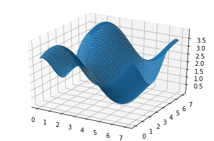

```python
axes = plt.subplot(projection='3d')
axes.plot_surface(X, Y, Z)
```

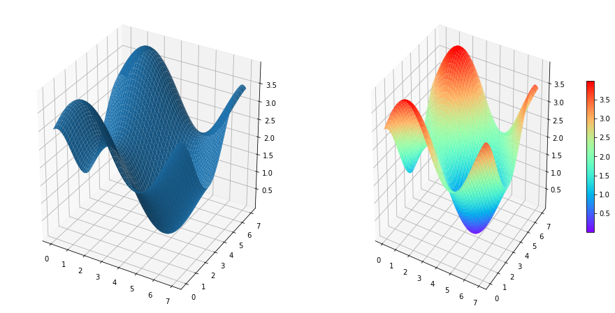

```python
plt.figure(figsize=(2*8,8))
axes1 = plt.subplot(1,2,1, projection='3d')
axes1.plot_surface(X, Y, Z)

axes2 = plt.subplot(1,2,2, projection='3d')
axes2 = axes2.plot_surface(X, Y, Z, cmap='rainbow')
# shrink长宽一起缩放
plt.colorbar(axes2, shrink=0.5)
```

## 玫瑰图/极坐标条形图(自学)

[figure not shown]

创建极坐标条形图

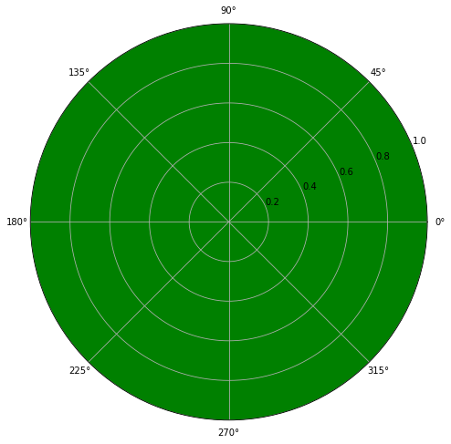

```python
plt.figure(figsize=(8,8))
plt.subplot(projection='polar', facecolor='g')
plt.bar()
```

```python
ravenna  = np.load('./Ravenna_wind.npy')
ravenna
```

```
array([ 10.    ,  20.    ,  40.    ,  90.    ,  87.    ,  79.    ,
        70.    ,  80.    ,  90.    ,  90.    , 105.    , 100.    ,
       110.    , 116.504 , 145.001 , 145.001 , 145.001 , 155.503 ,
       155.503 , 155.503 , 190.    , 126.501 , 250.    ,  99.0009,
       330.003 ,  20.    ,  70.    ,  70.    ,  10.    ,  80.    ,
       126.    , 100.    , 135.    , 130.    , 160.    , 130.501 ,
       190.    , 180.    , 193.502 , 193.502 , 224.004 , 224.004 ,
       224.004 , 180.    , 190.    , 254.001 , 257.503 , 190.    ,
       159.5   , 100.    ,  80.    ,  90.    ,  80.    ,  80.    ,
        90.    ,  90.    ,  90.    ,  97.    ,  89.    ,  88.0147,
       107.004 , 107.004 , 132.503 , 132.503 , 132.503 , 251.    ])
```

使用np.histogram计算一组数据的直方图

```python
data, data_range = np.histogram(ravenna, range=[0,360], bins=8)
```

```
<BarContainer object of 8 artists>
```

[figure not shown]

```python
plt.figure(figsize=(8,8))
plt.subplot(projection='polar', facecolor='g')
plt.bar(data_range, data, width=1)
```

```python
data
```

```
array([ 5, 12, 24,  9, 11,  4,  0,  1], dtype=int64)
```

```python
data_range
```

```
array([  0.,  45.,  90., 135., 180., 225., 270., 315., 360.])
```

```python
data_range = np.arange(0, 2*np.pi, 2*np.pi/8)
data_range
```

```
array([0.        , 0.78539816, 1.57079633, 2.35619449, 3.14159265,
       3.92699082, 4.71238898, 5.49778714])
```

```
<BarContainer object of 8 artists>
```

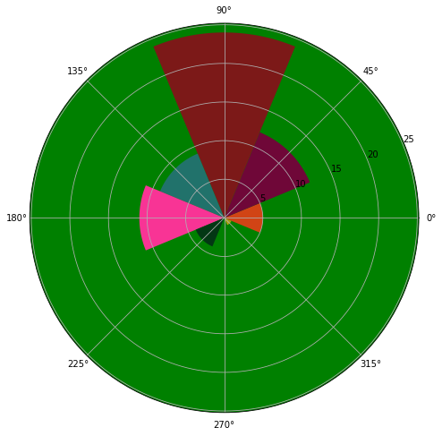

```python
plt.figure(figsize=(8,8))
plt.subplot(projection='polar', facecolor='g')
plt.bar(data_range, data,  color=np.random.rand(8,3), width=2*np.pi/8)
```